# SimpleRPGの作成（準備編）

> オブジェクト指向プログラミングおよび演習1 第5回,第6回

> テキストベースのシンプルなRPGを作成します。

今回作成するプログラムは、次回以降の「継承」や「抽象クラス」、「インターフェイス」を学ぶための基礎的なプログラムになります。

いままで学んだクラスやメソッドの書き方を使って、テキストベースのRPGのようなものを作成します。

この仕様に沿ったプログラムのソースコードは、資料として配布いたします。  
ソースコードをこの資料と照らし合わせて良くよみ、次回に備えてください。

# RPGの基礎部分を作成する

## 作成するところ

1. 勇者クラスの作成
2. 敵クラスの作成
3. 勇者クラスの行動メソッド実装
4. 敵クラスの行動メソッド実装
5. 勇者クラス、敵クラスを生成するクラスの作成
6. 勇者と敵キャラの戦闘処理

## プロジェクト設定

- プロジェクト名
  - `SimpleRPG`
- パッケージ
  - `jp.ac.ait.k00000`

# 詳細仕様

## 勇者クラス (Hero.java)

勇者のステータス、行動を定義するクラス

### フィールド

- `private String name`
  - 名前
- `private int hp`
  - 体力
- `private int atk`
  - 攻撃力
- `private int def`
  - 防御力
- `private int agi`
  - 素早さ

### コンストラクタ

- `public Hero(String name, int hp, int atk, int def, int agi)`
  - それぞれ引数の値で初期値セット
- `private Hero()`
  - privateにしておくことで外から呼ばれないようにします

### メソッド

#### アクセサメソッド

- `public String getName()` - 名前を返す
- `public void setName(String name)` - 名前を設定する
- `public int getHp()` - HPを返す
- `public int getAtk()` - ATKを返す
- `public int getDef()` - DEFを返す
- `public int getAgi()` - AGIを返す

#### 行動制御メソッド

- `private int calcAttackPoint(Enemy e)`
  - メソッドを呼び出した勇者が、引数の敵に与えられるダメージを計算して返します。（詳細は後述）
- `public int attack(Enemy e)`
  - 攻撃を行う。`calcAttackPoint()`にて計算されたダメージ量を引数の相手に与えます。(引数のオブジェクトの`damage()`メソッドを呼ぶ必要があります)この関数の戻り値は与えたダメージ(`calcAttackPoint()`で計算された値をそのまま返します。)
- `public int damage(int d)`
  - ダメージを受ける。対象はメソッドを呼び出した勇者クラスのインスタンス。  
    フィールドのhpから引数のダメージ分を減算し、0を下回る場合はhpに0を代入する。  
    戻り値はダメージを受けた後のhp。

## 敵クラス (Enemy.java)

敵のステータス、行動を定義するクラス

### フィールド

- `private String name`
  - 名前
- `private int hp`
  - 体力
- `private int atk`
  - 攻撃力
- `private int def`
  - 防御力
- `private int agi`
  - 素早さ

### コンストラクタ

- `public Enemy(String name, int hp, int atk, int def, int agi)`
  - それぞれ引数の値で初期値セット
- `private Enemy()`
  - privateにしておくことで外から呼ばれないようにします

### メソッド

#### アクセサメソッド

- `public String getName()`
- `public void setName(String name)`
- `public int getHp()`
- `public int getAtk()`
- `public int getDef()`
- `public int getAgi()`

#### 行動制御メソッド

- `private int calcAttackPoint(Hero e)`
  - メソッドを呼び出した敵が、引数の勇者に与えられるダメージを計算して返します。（詳細は後述）
- `public int attack(Hero e)`
  - 攻撃を行う。`calcAttackPoint()`にて計算されたダメージ量を引数の相手に与えます。(引数のオブジェクトの`damage()`メソッドを呼ぶ必要があります)この関数の戻り値は与えたダメージ(`calcAttackPoint()`で計算された値をそのまま返します。)
- `public int damage(int d)`
  - ダメージを受ける。対象はメソッドを呼び出した敵クラスのインスタンス。  
    フィールドのhpから引数のダメージ分を減算し、0を下回る場合はhpに0を代入する。  
    戻り値はダメージを受けた後のhp。

## ダメージ計算詳細

### 勇者 → 敵

敵キャラクターへ与えられるダメージ計算は以下の計算に従う。

| 条件（勇者のatk : 敵のdef） | ダメージ算出 |
| --- | --- |
| > | 勇者のatk × 1.4(小数点以下切り上げ) |
| == | 勇者のatk |
| < | 勇者のatk × 0.6(小数点以下切り上げ) |

上記計算したダメージから、ランダムに-3〜+3の変化を持たせます。

また、ダメージ量が0より下回ることはありません。

### 敵 → 勇者

勇者キャラクターへ与えられるダメージ計算は以下の計算に従う。

| 条件（敵のatk : 勇者のdef） | ダメージ算出 |
| --- | --- |
| > | 敵のatk × 1.4(小数点以下切り上げ) |
| == | 敵のatk |
| < | 敵のatk × 0.6(小数点以下切り上げ) |

上記計算したダメージから、ランダムに-3〜+3の変化を持たせます。

また、ダメージ量が0より下回ることはありません。

### 小数点以下切り上げ

`Math.ceil()`メソッドで切り上げができます。

## 攻撃メソッド(attack)について

勇者、敵クラスそれぞれのattackメソッドでは、与えるダメージを各オブジェクトのcalcAttackPointメソッドの戻り値から取得し、攻撃対象となる相手のオブジェクトのdamageメソッドでダメージを与えてください。

攻撃成功率は、現時点では100%とします。

attack()メソッドの戻り値は、calcAttackPoint()で算出された値を返してください。※実際に与えたダメージ量ではありません。

## 勇者や敵を生成するクラス(CharacterFactory.java)

勇者クラスのインスタンスや、敵クラスのインスタンスを生成して返すStaticなメソッドを持つクラス

勇者、敵などのキャラクターは、原則このクラスのクラスメソッドを用いて生成します。

### フィールド

- `private static final String[] ENEMY_NAMES = {"敵1", "敵2", "敵3", "敵4", "敵5"};`
  - 敵キャラクターの名前は、この配列よりランダムで選ばれます。

### コンストラクタ

なし

### メソッド

- `public static Hero createHero(String name)`
  - 勇者を生成して返すメソッド
  - 内部処理は、名前は引数の名前を使用し、それ以外のパラメータは後述するランダムでのパラメータ決定に従いインスタンスを生成し返します
- `public static Enemy createEnemy()`
  - 内部処理は、名前は`ENEMY_NAMES`の中からランダムに選んで使用し、それ以外のパラメータは後述するランダムでのパラメータ決定に従いインスタンスを生成し返します

#### キャラクター生成時のパラメータ初期値について

キャラクターのパラメータは、次の表にまとめられた範囲に従いランダムに決定させます。

##### 勇者の場合

| パラメータ | ランダム範囲 |
| --- | --- |
| HP | 80 〜 120 |
| ATK | 8 〜 15 |
| DEF | 8 〜 15 |
| AGI | 8 〜 15 |

##### 敵の場合

| パラメータ | ランダム範囲 |
| --- | --- |
| HP | 50 〜 200 |
| ATK | 5 〜 15 |
| DEF | 5 〜 10 |
| AGI | 10 〜 20 |

## メインクラス(SimpleRPG.java)

mainメソッドを持つクラス  
画面表示や画面からの入力は、すべてこのクラス内で行います。

### フィールド

なし

### コンストラクタ

なし

### メソッド

- `public static void main(String[] args)`
- その他必要に応じて追加してもよい

### mainメソッドでの処理の流れ

mainメソッド内でのゲームの進行(主要な部分のみ)は以下のフローに従ってください。

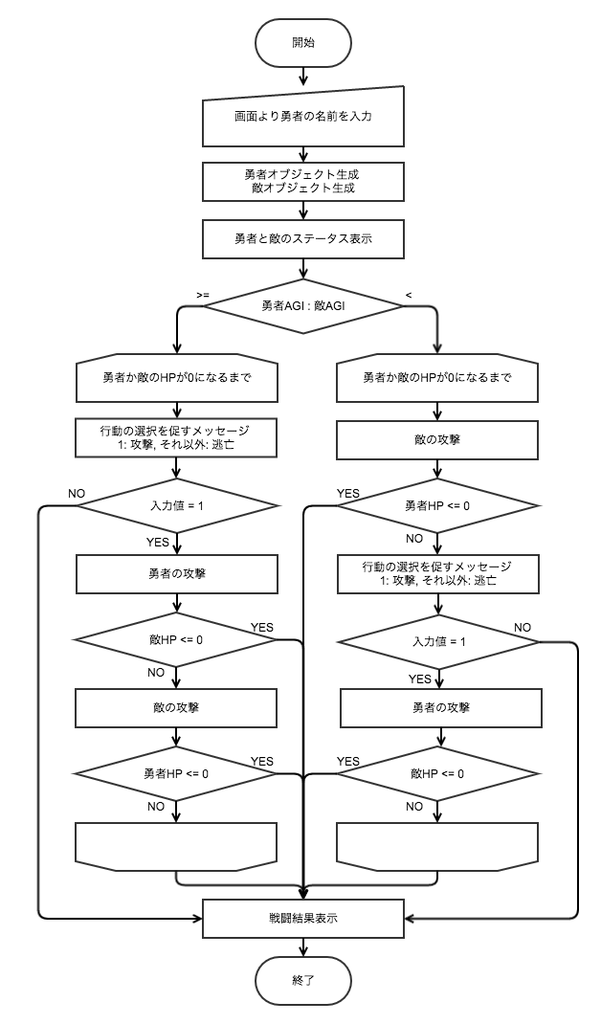

# 次回このプログラムをオブジェクト指向の便利なしくみを使って改良してきます。

配布資料には、以下の2つを用意しています。

1. `src`フォルダをzip圧縮したファイル
2. `SimpleRPG.jar`ファイル

特に1のJavaプログラムはしっかりと読み込んでおきましょう。